# Rendering the Boston Teapot

For my Final Project in CS 519: Scientific Visualization, I chose to create a volume rendering of the Boston Teapot, which is a data set from a CT scan of a teapot with a lobster inside. Since I am very inexperience in generating any sort of graphics, I decided to challenge myself to create renderings using 3 different methods. Below are the visual results of my efforts.

## ParaView

ParaView is an open-source, data analysis and visualization application [1]. Once I correctly imported the data set, I was able to create this initial rendering:

[figure not shown]

Using ParaView’s user friendly visual interface, I was able to extract the lobster and make adjustments in color mapping and opacity in order to improve the rendering as seen below:

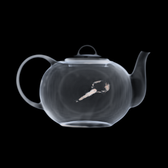

[figure not shown]

[figure not shown]

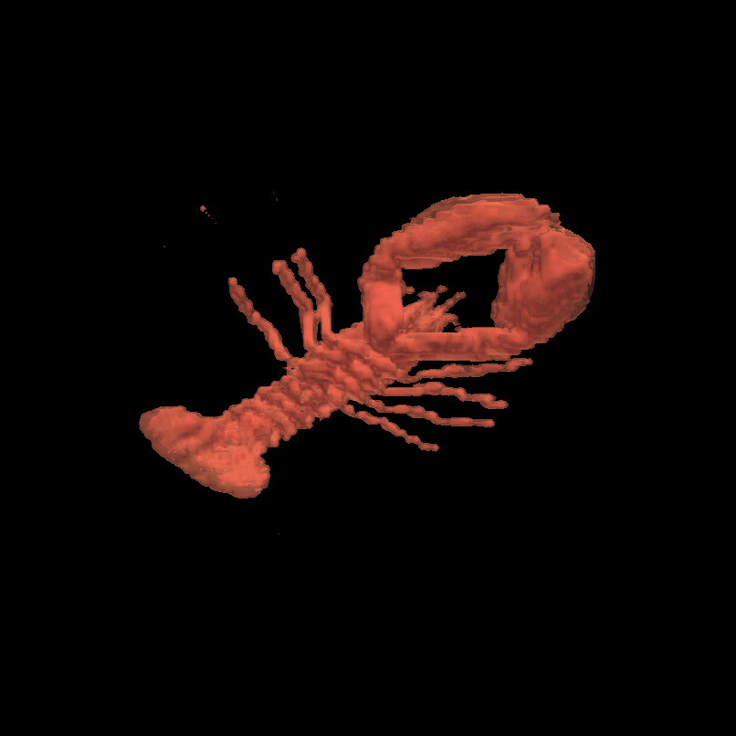

I was even able to create a rotating animation of the rendering and export the frames to create the .gif below.

[figure not shown]

## PyVista

PyVista is a “helper module for the Visualization Toolkit (VTK) that takes a different approach on interfacing with VTK through NumPy and direct array access.” [2] Using PyVista, I was able to extract the lobster as well as adjust the color mapping and opacity to mimic the rendering from ParaView, although, as you can see in the results below, the PyVista Rendering is not quite as refined as what I was able to produce in ParaView.

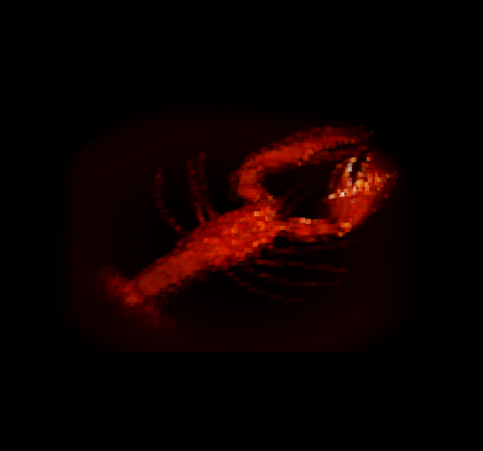

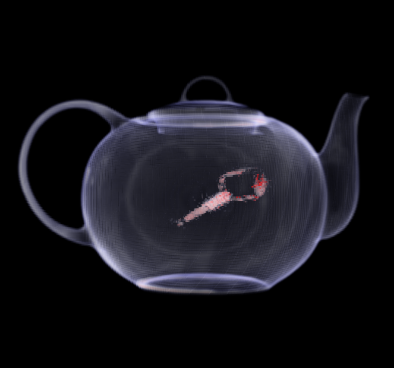

## VTK in Python

“VTK is an open-source toolkit for 3D computer graphics, image processing, and visualization.” [3] I put some effort into trying to learn how to code with VTK in python. Honestly, it was a win for me to able to generate a rendering at all. I was able to go a step further an add some color as well as tweak the opacity to create the rough rendering of the Boston Teapot below.

[figure not shown]

Source code for my PyVista an VTK renderings can be found in my submission folder as well as my formal report which contains the full details of my efforts for this project. Thanks!

**Resources**

[1] ParaView: https://www.paraview.org/overview/

[2] PyVista: https://docs.pyvista.org/

[3] VTK: https://pypi.org/project/vtk/